# exercise-10

Jyhreh Johnson

4/7/2022

1. Load in the Kamilar and Cooper (2013) dataset.

```r
library(tidyverse)
```

```r
library(ggpubr)
library(ggplot2)
f <- "https://raw.githubusercontent.com/difiore/ada-2022-datasets/main/KamilarAndCooperData.csv"
d <- read_csv(f, col_names = TRUE)
head(d)
```

```
## # A tibble: 6 × 44
##   Scientific_Name         Family Genus Species Brain_Size_Spec… Brain_Size_Fema…
##   <chr>                   <chr>  <chr> <chr>              <dbl>            <dbl>
## 1 Allenopithecus_nigrovi… Cerco… Alle… nigrov…             58.0             53.7
## 2 Allocebus_trichotis     Cerco… Allo… tricho…             NA               NA
## 3 Alouatta_belzebul       Ateli… Alou… belzeb…             52.8             51.2
## 4 Alouatta_caraya         Ateli… Alou… caraya              52.6             47.8
## 5 Alouatta_guariba        Ateli… Alou… guariba             51.7             49.1
## 6 Alouatta_palliata       Ateli… Alou… pallia…             49.9             48.0
## # … with 38 more variables: Brain_size_Ref <chr>, Body_mass_male_mean <dbl>,
## #   Body_mass_female_mean <dbl>, Mass_Dimorphism <dbl>, Mass_Ref <chr>,
## #   MeanGroupSize <dbl>, AdultMales <dbl>, AdultFemale <dbl>,
## #   AdultSexRatio <dbl>, Social_Organization_Ref <chr>,
## #   InterbirthInterval_d <dbl>, Gestation <dbl>, WeaningAge_d <dbl>,
## #   MaxLongevity_m <dbl>, LitterSz <dbl>, Life_History_Ref <chr>,
## #   GR_MidRangeLat_dd <dbl>, Precip_Mean_mm <dbl>, Temp_Mean_degC <dbl>, …
```

2. Plot lifespan (MaxLongevity_m) versus female body mass (Body mass female mean).

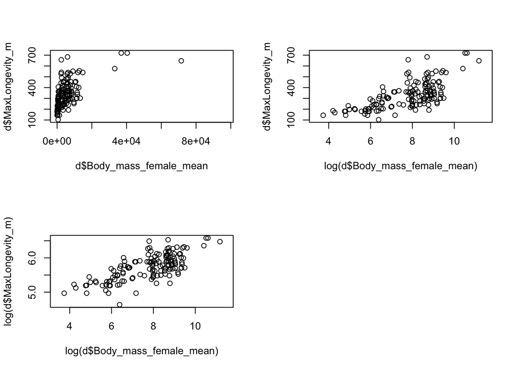

```r
#Plot lifespan v body mass
par(mfrow = c(2, 2))
plot(d$Body_mass_female_mean, d$MaxLongevity_m)
plot(log(d$Body_mass_female_mean), d$MaxLongevity_m)
plot(log(d$Body_mass_female_mean), log(d$MaxLongevity_m))
```

**Question** Is the relationship linear? - The relationship of the last two plots do appear to be linear, while the first plot does not show a linear relationship.

3. Run linear models of lifespan ~ female body mass, lifespan ~ log(female body mass), and log(lifespan) ~ log(female body mass).

```r
#Create the models
ls_m1 <- lm(data = d, MaxLongevity_m ~ Body_mass_female_mean)
ls_m2 <- lm(data = d, MaxLongevity_m ~ log(Body_mass_female_mean))
ls_m3 <- lm(data = d, log(MaxLongevity_m) ~ log(Body_mass_female_mean))

ls_m1
```

```
##
## Call:
## lm(formula = MaxLongevity_m ~ Body_mass_female_mean, data = d)
##
## Coefficients:
##           (Intercept)  Body_mass_female_mean
##             283.47213                0.00905
```

```r
ls_m2
```

```
##
## Call:
## lm(formula = MaxLongevity_m ~ log(Body_mass_female_mean), data = d)
##
## Coefficients:
##                (Intercept)  log(Body_mass_female_mean)
##                    -128.86                       59.34
```

```r
ls_m3
```

```
##
## Call:
## lm(formula = log(MaxLongevity_m) ~ log(Body_mass_female_mean),
##     data = d)
##
## Coefficients:
##                (Intercept)  log(Body_mass_female_mean)
##                      4.259                       0.190
```

4. Generate the residuals for all three linear models, plot them in relation to the corresponding explanatory variable, and make histograms of the residuals.

```r
#Find the residuals
m1_res <- ls_m1$residuals
m2_res <- ls_m2$residuals
m3_res <- ls_m3$residuals

m1_res
```

[output not shown]

```r
m2_res
```

[output not shown]

```r
m3_res
```

[output not shown]

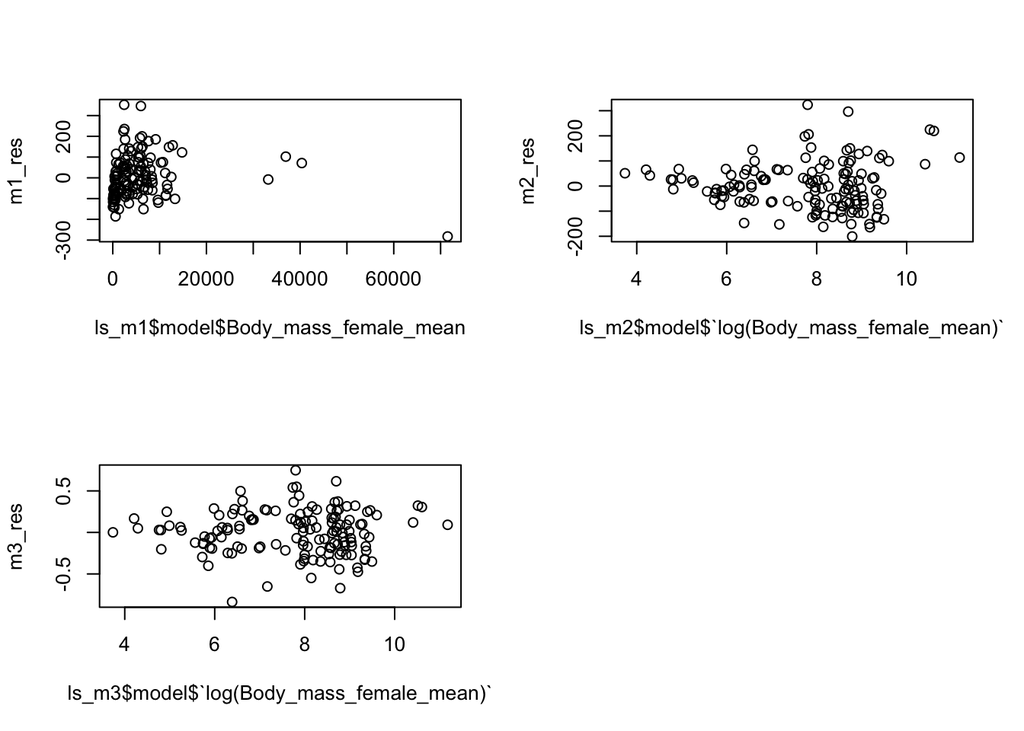

```r
#Plot them in relation to the corresponding explanatory variable
par(mfrow = c(2, 2))
plot(ls_m1$model$Body_mass_female_mean, m1_res)
plot(ls_m2$model$`log(Body_mass_female_mean)`, m2_res)
plot(ls_m3$model$`log(Body_mass_female_mean)`, m3_res)


#make histograms
par(mfrow = c(2, 2))
```

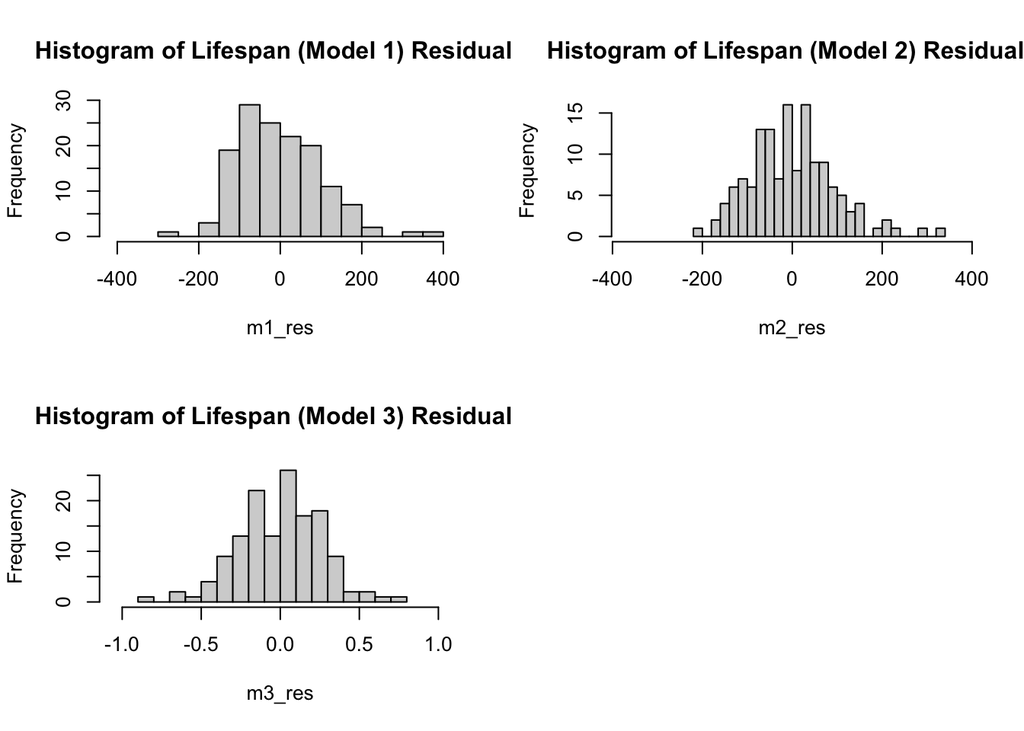

```r
hist(m1_res, xlim = c(-4 * sd(m1_res), 4 * sd(m1_res)), breaks = 20, main = "Histogram of Lifespan (Model 1) Residuals")

hist(m2_res, xlim = c(-4 * sd(m2_res), 4 * sd(m2_res)), breaks = 20, main = "Histogram of Lifespan (Model 2) Residuals")

hist(m3_res, xlim = c(-4 * sd(m3_res), 4 * sd(m3_res)), breaks = 20, main = "Histogram of Lifespan (Model 3) Residuals")
```

**Question** Do they appear to be normally distributed? - The histograms do seem to be normally distributed.

5. Generate the QQ plots for all three linear models.

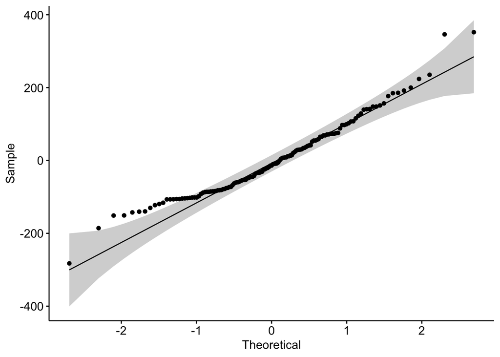

```r
#Create QQ Plots
ggqqplot(ls_m1$residuals)
```

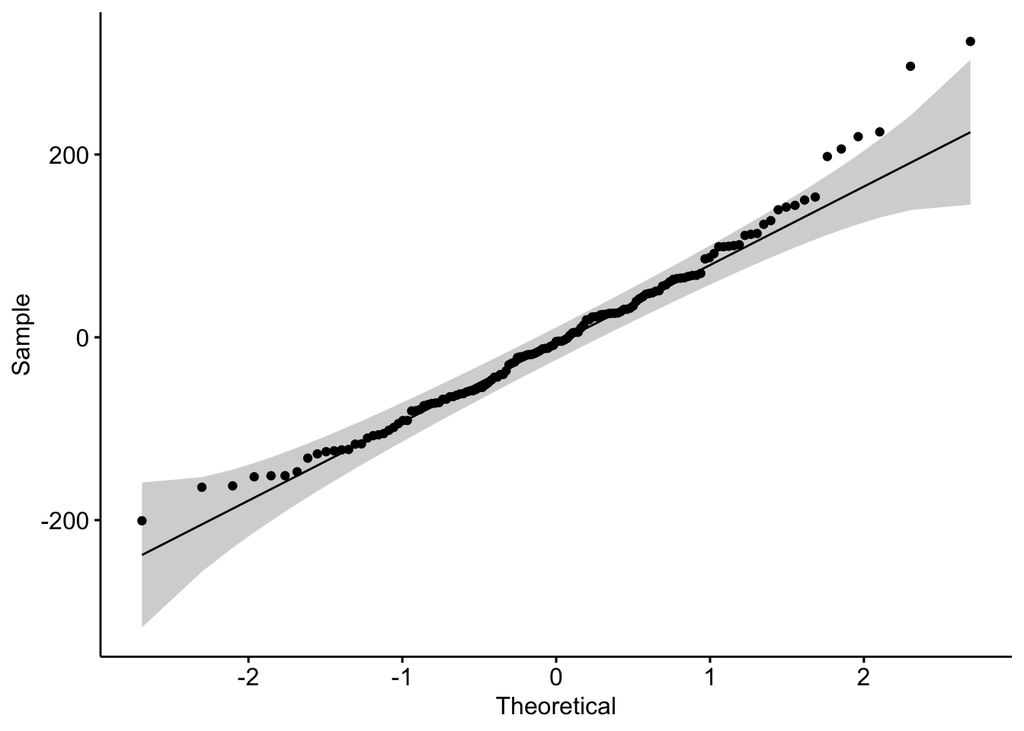

```r
ggqqplot(ls_m2$residuals)
```

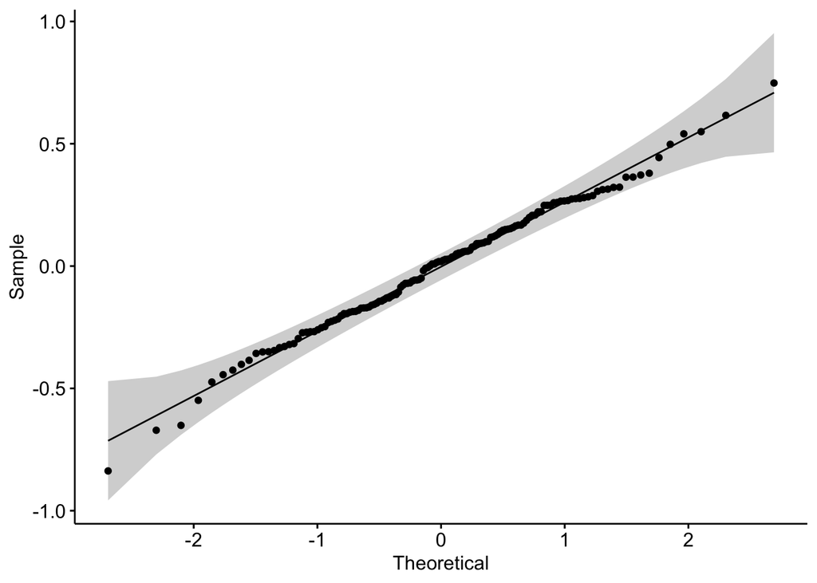

```r
ggqqplot(ls_m3$residuals)
```

**Question** Do they appear to be normally distributed? - Yes, as they more or less fall on or near the linear line.

6. Run the plot command for all three models.

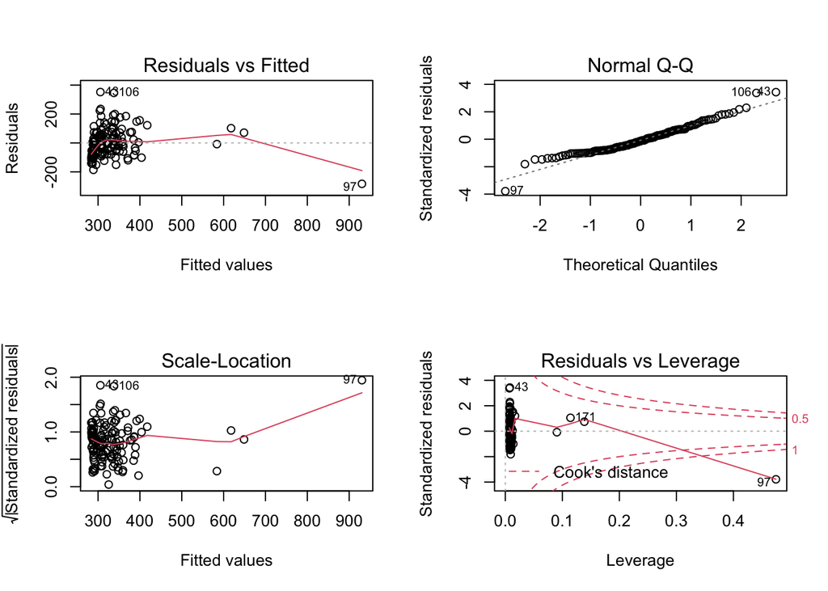

```r
par(mfrow = c(2, 2))
plot(ls_m1)
```

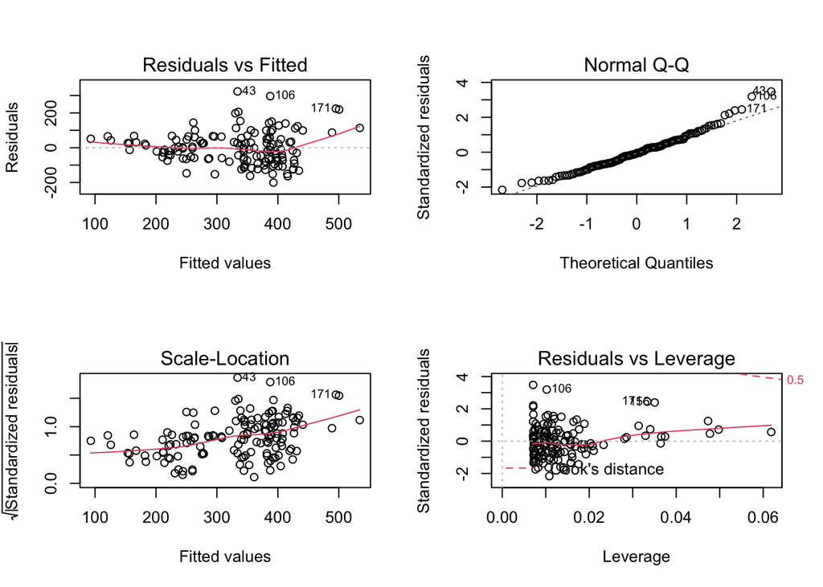

```r
plot(ls_m2)
```

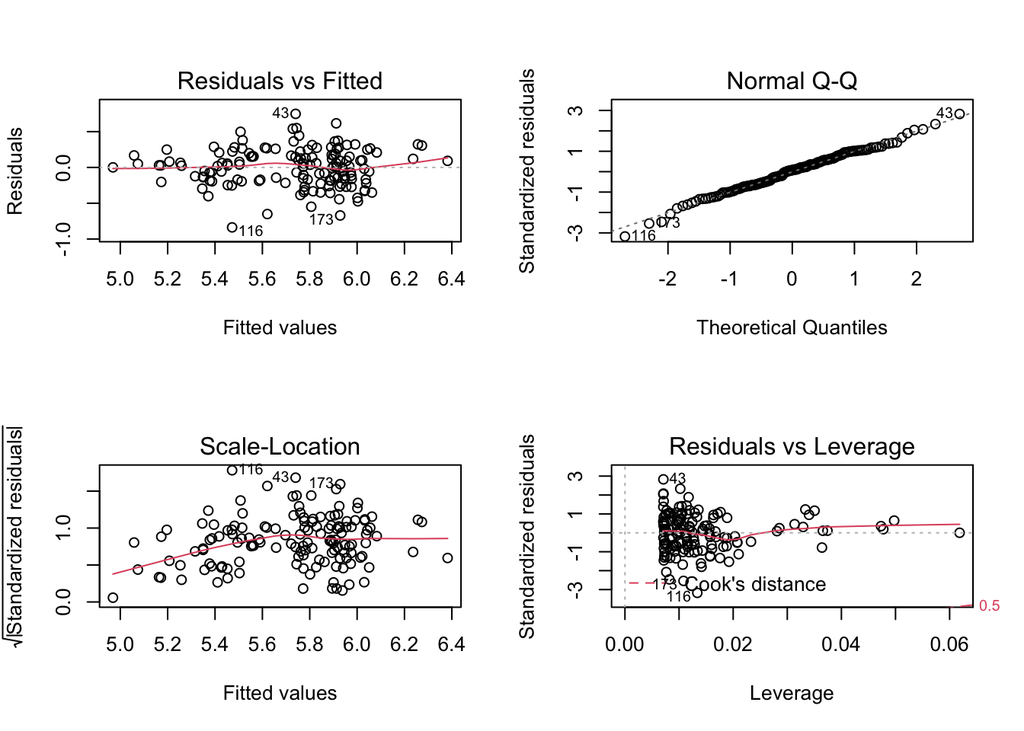

```r
plot(ls_m3)
```

7. Run a Shapiro-Wilk test on residuals for all three models.

```r
#Run the Shapiro-Wilk test
s1 <- shapiro.test(ls_m1$residuals)
s2 <- shapiro.test(ls_m2$residuals)
s3 <- shapiro.test(ls_m3$residuals)

s1
```

```
##
##  Shapiro-Wilk normality test
##
## data:  ls_m1$residuals
## W = 0.96352, p-value = 0.0008238
```

```r
s2
```

```
##
##  Shapiro-Wilk normality test
##
## data:  ls_m2$residuals
## W = 0.97515, p-value = 0.01131
```

```r
s3
```

```
##
##  Shapiro-Wilk normality test
##
## data:  ls_m3$residuals
## W = 0.99319, p-value = 0.7403
```